# Exercise 4

```r
date()
```

```
## [1] "Mon Nov 27 10:26:59 2023"
```

First, I need to load the “Boston” data from the MASS package: (And apparently I have to excplicitly set the CRAN mirror, otherwise knitting does not work)

```r
options(repos = c(CRAN = "https://cran.rstudio.com"))
install.packages("MASS")
library(MASS)
```

Loading the Boston dataset and exploring the structure:

```r
data(Boston)
str (Boston)
```

```
## 'data.frame':    506 obs. of  14 variables:
##  $ crim   : num  0.00632 0.02731 0.02729 0.03237 0.06905 ...
##  $ zn     : num  18 0 0 0 0 0 12.5 12.5 12.5 12.5 ...
##  $ indus  : num  2.31 7.07 7.07 2.18 2.18 2.18 7.87 7.87 7.87 7.87 ...
##  $ chas   : int  0 0 0 0 0 0 0 0 0 0 ...
##  $ nox    : num  0.538 0.469 0.469 0.458 0.458 0.458 0.524 0.524 0.524 0.524 ...
##  $ rm     : num  6.58 6.42 7.18 7 7.15 ...
##  $ age    : num  65.2 78.9 61.1 45.8 54.2 58.7 66.6 96.1 100 85.9 ...
##  $ dis    : num  4.09 4.97 4.97 6.06 6.06 ...
##  $ rad    : int  1 2 2 3 3 3 5 5 5 5 ...
##  $ tax    : num  296 242 242 222 222 222 311 311 311 311 ...
##  $ ptratio: num  15.3 17.8 17.8 18.7 18.7 18.7 15.2 15.2 15.2 15.2 ...
##  $ black  : num  397 397 393 395 397 ...
##  $ lstat  : num  4.98 9.14 4.03 2.94 5.33 ...
##  $ medv   : num  24 21.6 34.7 33.4 36.2 28.7 22.9 27.1 16.5 18.9 ...
```

```r
dim(Boston)
```

```
## [1] 506  14
```

The Boston dataset shows the housing values in different suburbs of Boston. The dataframe has a total of 506 observations of 14 variables. I explain the variables below: crim: per capita crime rate by town zn: proportion of residential land zoned for lots over 25,000 sq.ft. indus: proportion of non-retail business acres per town. chas: Charles River dummy variable (= 1 if tract bounds river; 0 otherwise). nox: nitrogen oxides concentration (parts per 10 million). rm: average number of rooms per dwelling. age: proportion of owner-occupied units built prior to 1940. dis: weighted mean of distances to five Boston employment centres. rad: index of accessibility to radial highways. tax: full-value property-tax rate per $10,000. ptratio: pupil-teacher ratio by town. black: the proporotion of blacks by town lstat: lower status of the population (percent). medv: median value of owner-occupied homes in $1000s.

**Next, let us examine the data and try to figure out what is going on here:**

```r
summary(Boston)
```

```
##       crim                zn             indus            chas
##  Min.   : 0.00632   Min.   :  0.00   Min.   : 0.46   Min.   :0.00000
##  1st Qu.: 0.08205   1st Qu.:  0.00   1st Qu.: 5.19   1st Qu.:0.00000
##  Median : 0.25651   Median :  0.00   Median : 9.69   Median :0.00000
##  Mean   : 3.61352   Mean   : 11.36   Mean   :11.14   Mean   :0.06917
##  3rd Qu.: 3.67708   3rd Qu.: 12.50   3rd Qu.:18.10   3rd Qu.:0.00000
##  Max.   :88.97620   Max.   :100.00   Max.   :27.74   Max.   :1.00000
##       nox               rm             age              dis
##  Min.   :0.3850   Min.   :3.561   Min.   :  2.90   Min.   : 1.130
##  1st Qu.:0.4490   1st Qu.:5.886   1st Qu.: 45.02   1st Qu.: 2.100
##  Median :0.5380   Median :6.208   Median : 77.50   Median : 3.207
##  Mean   :0.5547   Mean   :6.285   Mean   : 68.57   Mean   : 3.795
##  3rd Qu.:0.6240   3rd Qu.:6.623   3rd Qu.: 94.08   3rd Qu.: 5.188
##  Max.   :0.8710   Max.   :8.780   Max.   :100.00   Max.   :12.127
##       rad              tax           ptratio          black
##  Min.   : 1.000   Min.   :187.0   Min.   :12.60   Min.   :  0.32
##  1st Qu.: 4.000   1st Qu.:279.0   1st Qu.:17.40   1st Qu.:375.38
##  Median : 5.000   Median :330.0   Median :19.05   Median :391.44
##  Mean   : 9.549   Mean   :408.2   Mean   :18.46   Mean   :356.67
##  3rd Qu.:24.000   3rd Qu.:666.0   3rd Qu.:20.20   3rd Qu.:396.23
##  Max.   :24.000   Max.   :711.0   Max.   :22.00   Max.   :396.90
##      lstat            medv
##  Min.   : 1.73   Min.   : 5.00
##  1st Qu.: 6.95   1st Qu.:17.02
##  Median :11.36   Median :21.20
##  Mean   :12.65   Mean   :22.53
##  3rd Qu.:16.95   3rd Qu.:25.00
##  Max.   :37.97   Max.   :50.00
```

Here we have all the observations of all variables summarized. The median crime rate seems to be very low compare to the max (0.25 vs. 88.9), which implies that there is some suburbs with extremely large crime rate compared to the rest. It is important to note that the “chas” is a dummy variable that is either 1 if the tract is next to the Charles River and 0 otherwise. The median value of homes has also a large variance, which is of course expected.

**Let us next visualize the data graphically:**

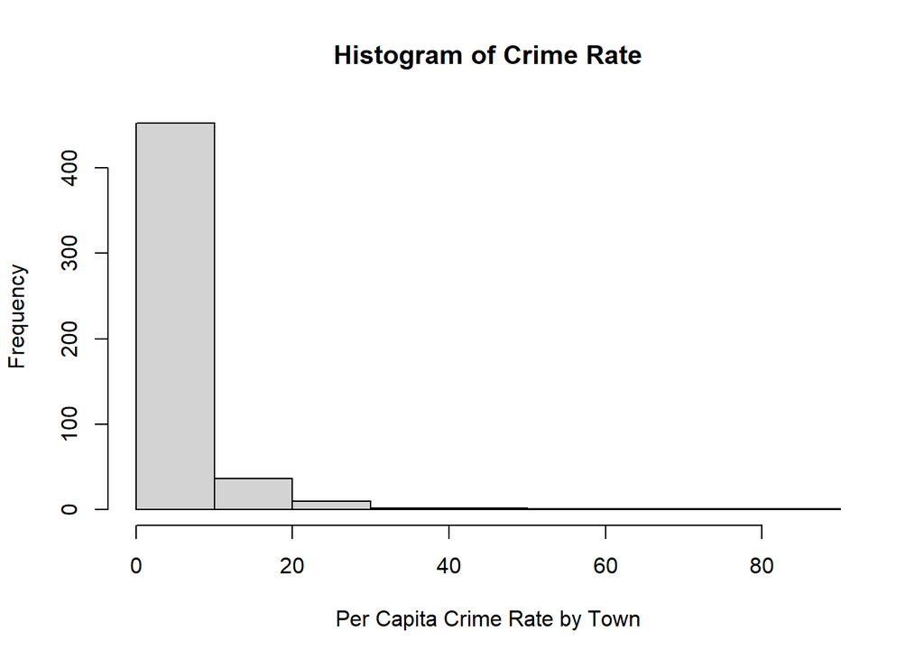

```r
# Histogram for per capita crime rate by town
hist(Boston$crim, main="Histogram of Crime Rate", xlab="Per Capita Crime Rate by Town")
```

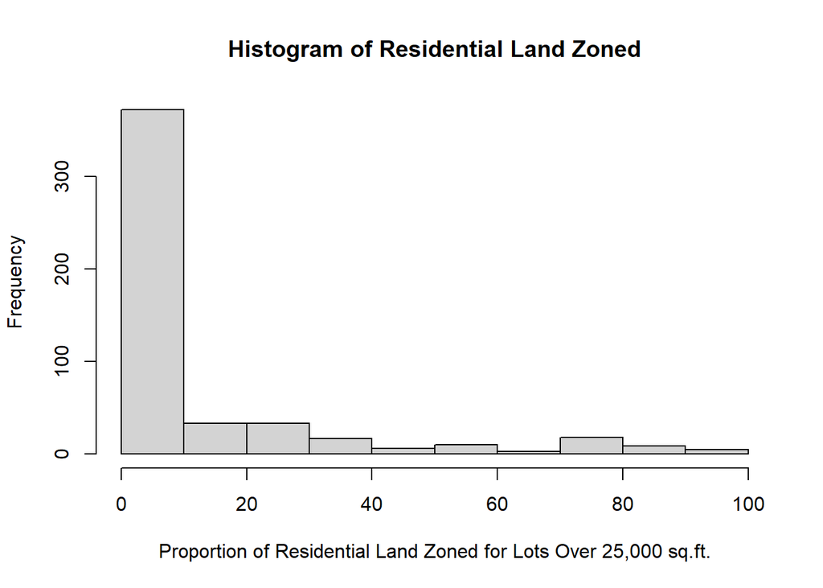

```r
# Histogram for proportion of residential land zoned for lots over 25,000 sq.ft.
hist(Boston$zn, main="Histogram of Residential Land Zoned", xlab="Proportion of Residential Land Zoned for Lots Over 25,000 sq.ft.")
```

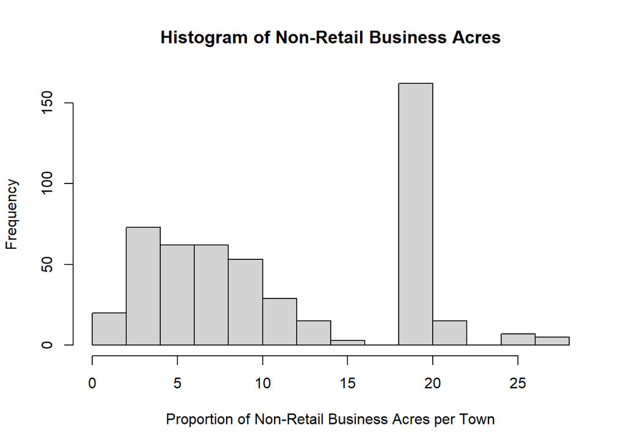

```r
# Histogram for proportion of non-retail business acres per town
hist(Boston$indus, main="Histogram of Non-Retail Business Acres", xlab="Proportion of Non-Retail Business Acres per Town")
```

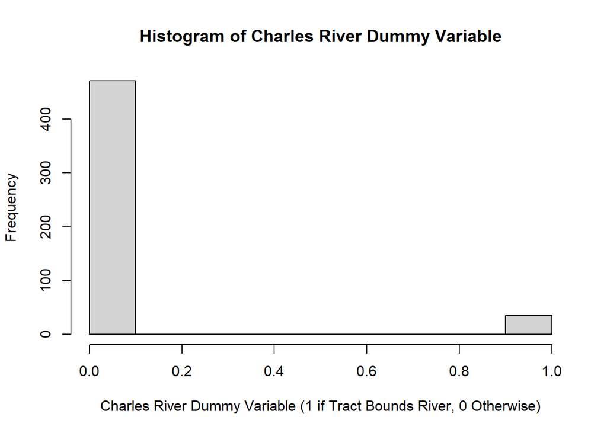

```r
# Histogram for Charles River dummy variable
hist(Boston$chas, main="Histogram of Charles River Dummy Variable", xlab="Charles River Dummy Variable (1 if Tract Bounds River, 0 Otherwise)")
```

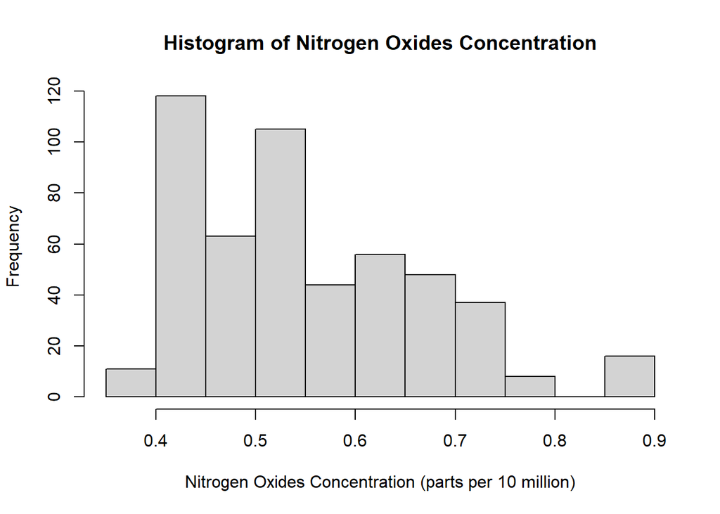

```r
# Histogram for nitrogen oxides concentration
hist(Boston$nox, main="Histogram of Nitrogen Oxides Concentration", xlab="Nitrogen Oxides Concentration (parts per 10 million)")
```

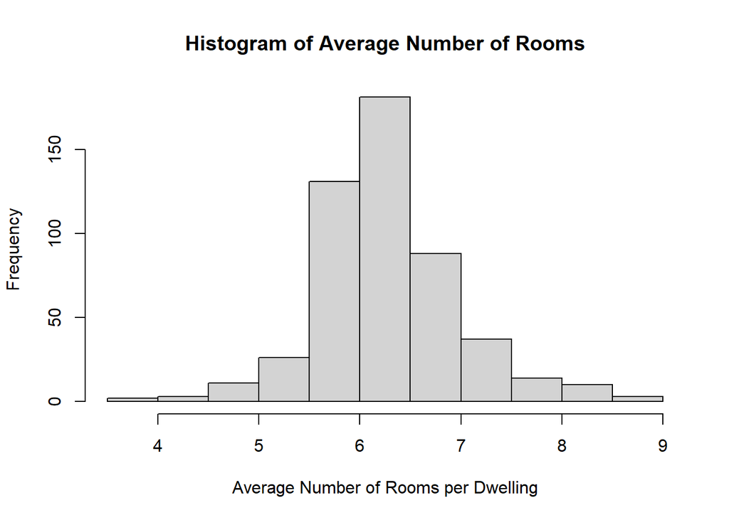

```r
# Histogram for average number of rooms per dwelling
hist(Boston$rm, main="Histogram of Average Number of Rooms", xlab="Average Number of Rooms per Dwelling")
```

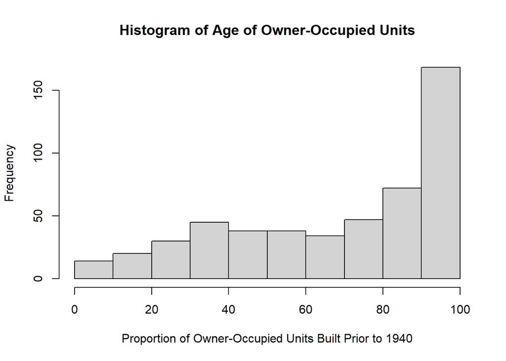

```r
# Histogram for proportion of owner-occupied units built prior to 1940
hist(Boston$age, main="Histogram of Age of Owner-Occupied Units", xlab="Proportion of Owner-Occupied Units Built Prior to 1940")
```

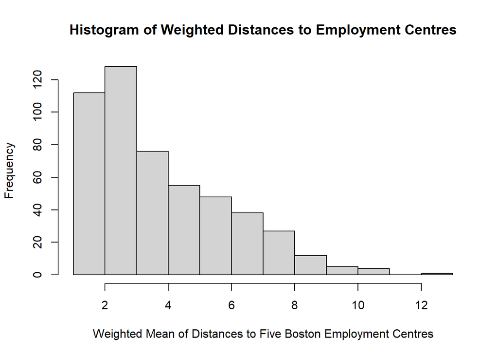

```r
# Histogram for weighted mean of distances to five Boston employment centres
hist(Boston$dis, main="Histogram of Weighted Distances to Employment Centres", xlab="Weighted Mean of Distances to Five Boston Employment Centres")
```

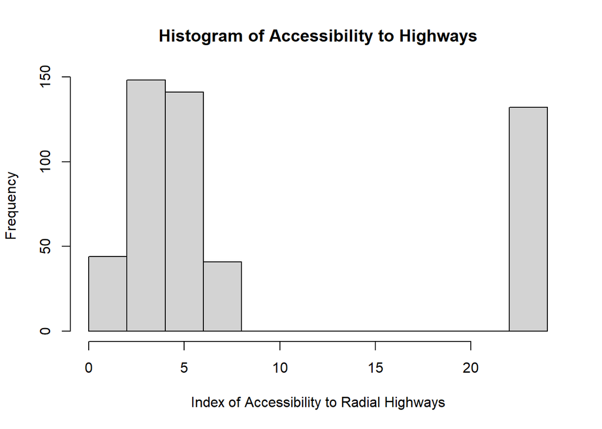

```r
# Histogram for index of accessibility to radial highways
hist(Boston$rad, main="Histogram of Accessibility to Highways", xlab="Index of Accessibility to Radial Highways")
```

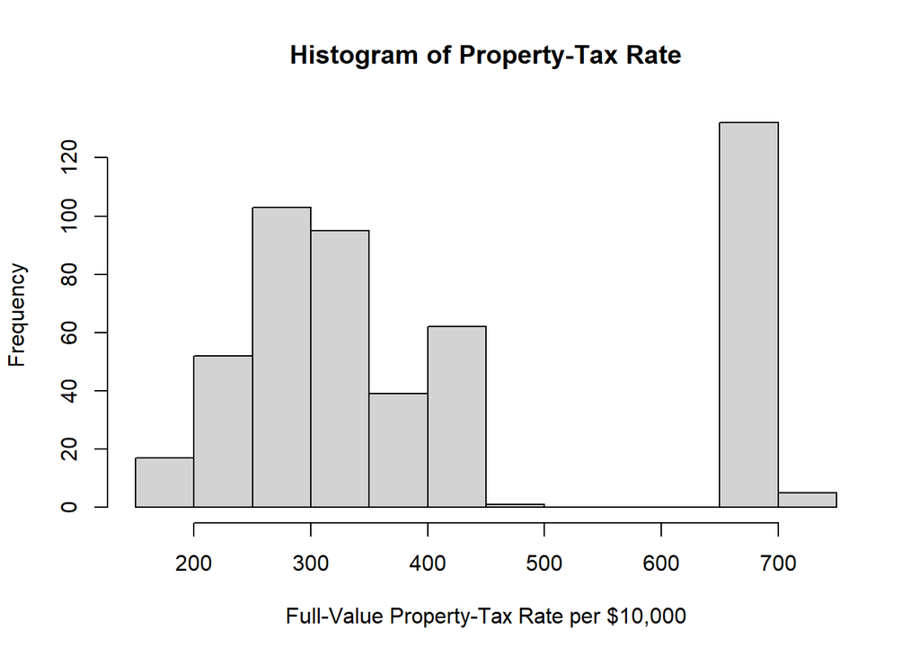

```r
# Histogram for full-value property-tax rate per $10,000
hist(Boston$tax, main="Histogram of Property-Tax Rate", xlab="Full-Value Property-Tax Rate per $10,000")
```

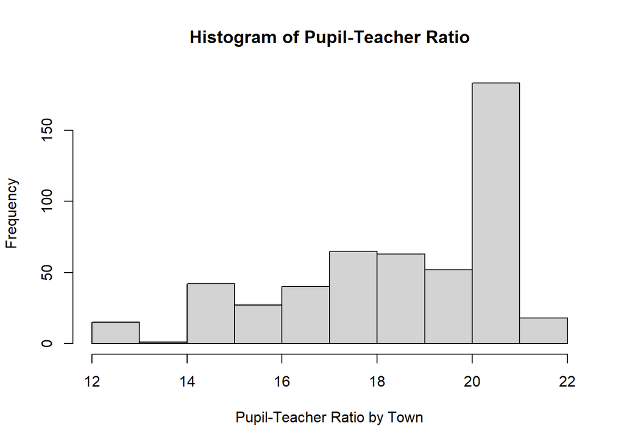

```r
# Histogram for pupil-teacher ratio by town
hist(Boston$ptratio, main="Histogram of Pupil-Teacher Ratio", xlab="Pupil-Teacher Ratio by Town")
```

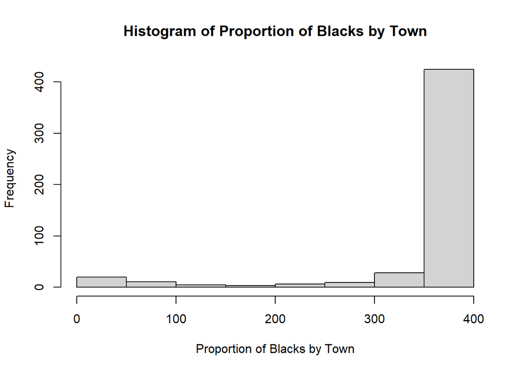

```r
# Histogram for the proportion of blacks by town
hist(Boston$black, main="Histogram of Proportion of Blacks by Town", xlab="Proportion of Blacks by Town")
```

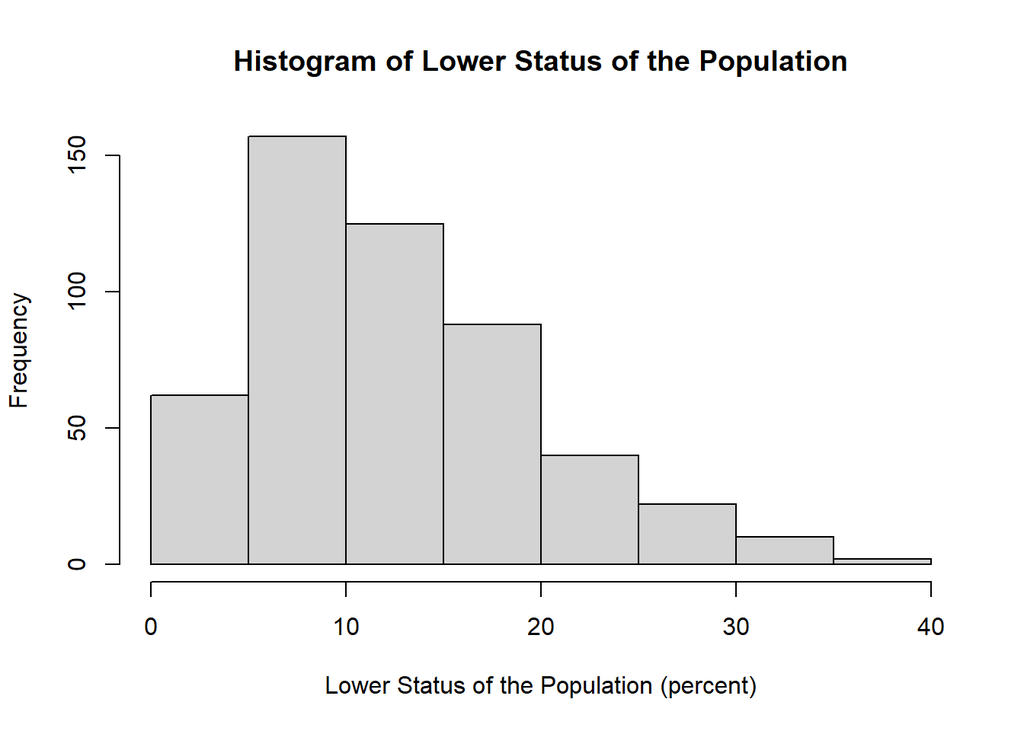

```r
# Histogram for lower status of the population
hist(Boston$lstat, main="Histogram of Lower Status of the Population", xlab="Lower Status of the Population (percent)")
```

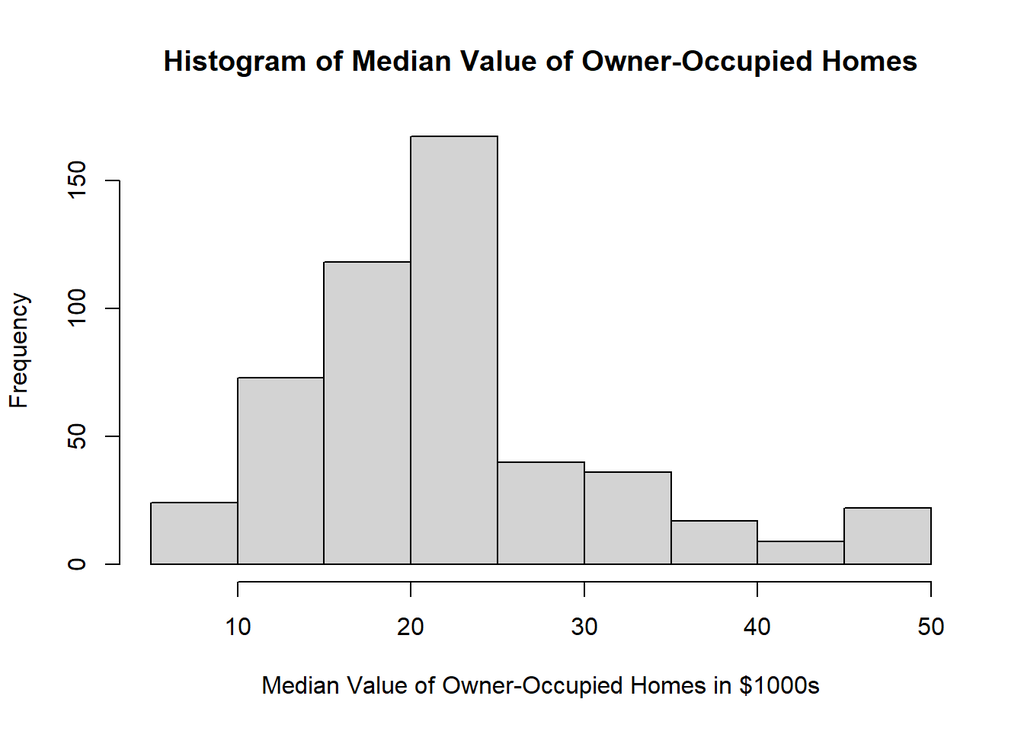

```r
# Histogram for median value of owner-occupied homes in $1000s
hist(Boston$medv, main="Histogram of Median Value of Owner-Occupied Homes", xlab="Median Value of Owner-Occupied Homes in $1000s")
```

It seems like crime rates, The proportion of residential land zoned and the proprtion of blacks in the population are variables that are distributed very unevenly. Let us analyze some correlations of the variables:

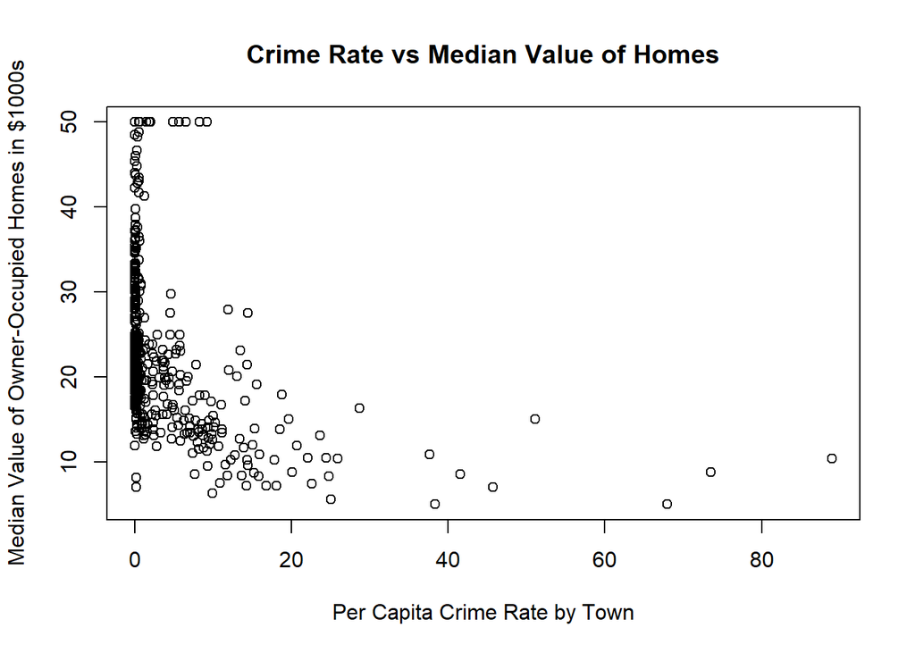

```r
plot(Boston$crim, Boston$medv, main="Crime Rate vs Median Value of Homes", xlab="Per Capita Crime Rate by Town", ylab="Median Value of Owner-Occupied Homes in $1000s")
```

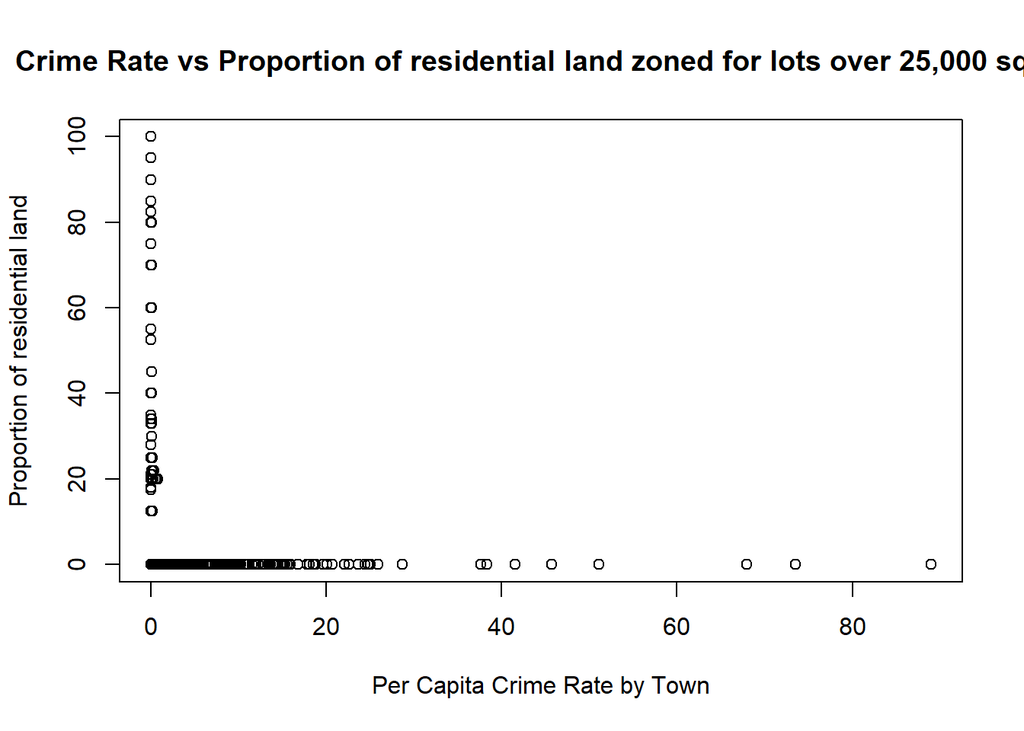

```r
plot(Boston$crim, Boston$zn, main="Crime Rate vs Proportion of residential land zoned for lots over 25,000 sq.ft.", xlab="Per Capita Crime Rate by Town", ylab="Proportion of residential land")
```

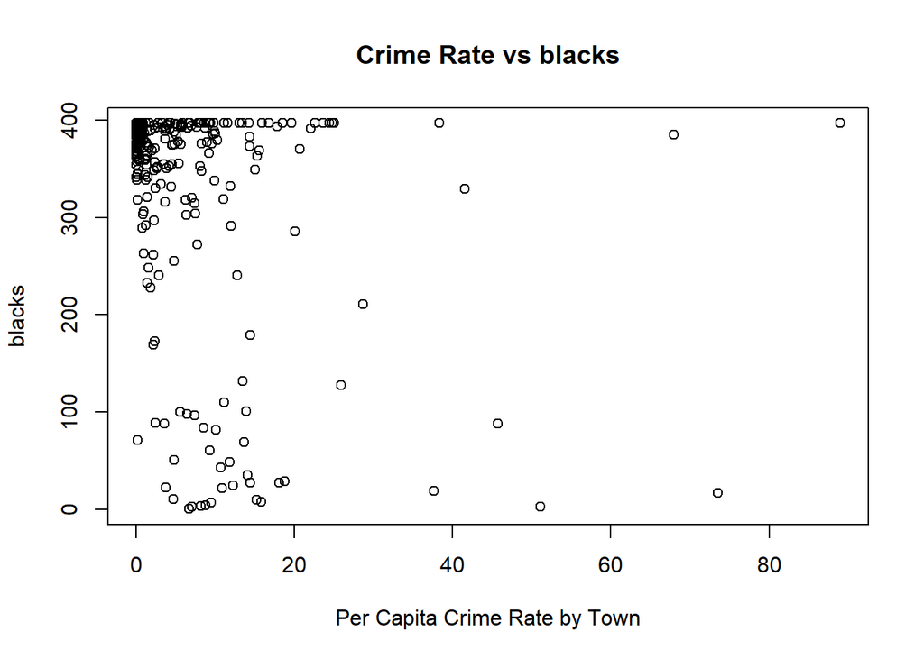

```r
plot(Boston$crim, Boston$black, main="Crime Rate vs blacks", xlab="Per Capita Crime Rate by Town", ylab="blacks")
```

By comparing a few different variables, we see that the low crime rate seems to correlate with the median value of homes and with the proportion of large residential plots. This is intuitive, as cheaper areas tend to have higher crime rate. In addition, a low proportion of large residential plots suggests that the area is more urban, which also intuitively correlates with a higher crime rates. The proportion of blacks in the population does not seem to have any correlation with the crime rates.

**Next, let us standardize the dataset**

```r
Boston_scaled <- scale(Boston)
Boston_scaled <- as.data.frame(Boston_scaled)
summary(Boston_scaled)
```

```
##       crim                 zn               indus              chas
##  Min.   :-0.419367   Min.   :-0.48724   Min.   :-1.5563   Min.   :-0.2723
##  1st Qu.:-0.410563   1st Qu.:-0.48724   1st Qu.:-0.8668   1st Qu.:-0.2723
##  Median :-0.390280   Median :-0.48724   Median :-0.2109   Median :-0.2723
##  Mean   : 0.000000   Mean   : 0.00000   Mean   : 0.0000   Mean   : 0.0000
##  3rd Qu.: 0.007389   3rd Qu.: 0.04872   3rd Qu.: 1.0150   3rd Qu.:-0.2723
##  Max.   : 9.924110   Max.   : 3.80047   Max.   : 2.4202   Max.   : 3.6648
##       nox                rm               age               dis
##  Min.   :-1.4644   Min.   :-3.8764   Min.   :-2.3331   Min.   :-1.2658
##  1st Qu.:-0.9121   1st Qu.:-0.5681   1st Qu.:-0.8366   1st Qu.:-0.8049
##  Median :-0.1441   Median :-0.1084   Median : 0.3171   Median :-0.2790
##  Mean   : 0.0000   Mean   : 0.0000   Mean   : 0.0000   Mean   : 0.0000
##  3rd Qu.: 0.5981   3rd Qu.: 0.4823   3rd Qu.: 0.9059   3rd Qu.: 0.6617
##  Max.   : 2.7296   Max.   : 3.5515   Max.   : 1.1164   Max.   : 3.9566
##       rad               tax             ptratio            black
##  Min.   :-0.9819   Min.   :-1.3127   Min.   :-2.7047   Min.   :-3.9033
##  1st Qu.:-0.6373   1st Qu.:-0.7668   1st Qu.:-0.4876   1st Qu.: 0.2049
##  Median :-0.5225   Median :-0.4642   Median : 0.2746   Median : 0.3808
##  Mean   : 0.0000   Mean   : 0.0000   Mean   : 0.0000   Mean   : 0.0000
##  3rd Qu.: 1.6596   3rd Qu.: 1.5294   3rd Qu.: 0.8058   3rd Qu.: 0.4332
##  Max.   : 1.6596   Max.   : 1.7964   Max.   : 1.6372   Max.   : 0.4406
##      lstat              medv
##  Min.   :-1.5296   Min.   :-1.9063
##  1st Qu.:-0.7986   1st Qu.:-0.5989
##  Median :-0.1811   Median :-0.1449
##  Mean   : 0.0000   Mean   : 0.0000
##  3rd Qu.: 0.6024   3rd Qu.: 0.2683
##  Max.   : 3.5453   Max.   : 2.9865
```

In the standardized dataset, the mean of each variable should be very close to 0, which seems correct by our summary. This also implies that the standard deviation of each variable should be close to 1.

**Next,We do the following: Create a categorical variable of the crime rate in the Boston dataset (from the scaled crime rate). Use the quantiles as the break points in the categorical variable. Drop the old crime rate variable from the dataset. Divide the dataset to train and test sets, so that 80% of the data belongs to the train set.**

```r
crime_quantiles <- quantile(Boston_scaled[, "crim"])
Boston_scaled$crime_cat <- cut(Boston_scaled[, "crim"], breaks = crime_quantiles, include.lowest = TRUE, labels = FALSE)

# Drop the old crime rate variable
Boston_scaled$crim <- NULL

install.packages("caTools")
library(caTools)
# Splitting the dataset into train and test sets
set.seed(123)  # Setting seed for reproducibility
split <- sample.split(Boston_scaled, SplitRatio = 0.8)  # Splitting
train_set <- subset(Boston_scaled, split == TRUE)  # 80% for training
test_set <- subset(Boston_scaled, split == FALSE)  # 20% for testing
```

Now we have created the test set and the train set. **NExt, we fit the linear discriminant analysis on the train set:**

```r
lda_model <- lda(crime_cat ~ ., data = train_set)
print(lda_model)
```

```
## Call:
## lda(crime_cat ~ ., data = train_set)
##
## Prior probabilities of groups:
##         1         2         3         4
## 0.2487437 0.2537688 0.2462312 0.2512563
##
## Group means:
##           zn      indus        chas        nox         rm        age        dis
## 1  0.9571563 -0.9128592 -0.07348562 -0.8749222  0.4358624 -0.8738589  0.9042847
## 2 -0.1270298 -0.2514731 -0.03844192 -0.5650634 -0.1582777 -0.3891141  0.3305265
## 3 -0.3804849  0.1833750  0.24993933  0.4047974  0.1464180  0.4758085 -0.3724963
## 4 -0.4872402  1.0171519 -0.03610305  1.0728118 -0.3787474  0.8348153 -0.8576564
##          rad        tax     ptratio       black        lstat        medv
## 1 -0.7057751 -0.7561490 -0.44416554  0.38231109 -0.765572825  0.52668332
## 2 -0.5565973 -0.4677967 -0.04851787  0.34306993 -0.153219847 -0.01573186
## 3 -0.4275601 -0.3229011 -0.30326583  0.04969264 -0.005758873  0.16562998
## 4  1.6377820  1.5138081  0.78037363 -0.72434339  0.882058886 -0.71716121
##
## Coefficients of linear discriminants:
##                  LD1         LD2         LD3
## zn       0.083062338  0.66201394 -1.02636397
## indus    0.046215842 -0.18394575  0.31434898
## chas    -0.111398646 -0.01334864  0.02631853
## nox      0.334352217 -0.82754017 -1.18586343
## rm      -0.109492585 -0.10365683 -0.17007976
## age      0.294574324 -0.46196563 -0.42597863
## dis     -0.032506167 -0.31732838 -0.01701235
## rad      3.423554045  0.86910593 -0.17987617
## tax      0.002905467  0.05865570  0.60678890
## ptratio  0.083078496  0.03600063 -0.30013587
## black   -0.077883429  0.03383353  0.16878604
## lstat    0.214422789 -0.12956856  0.36397272
## medv     0.189930282 -0.36847262 -0.18211656
##
## Proportion of trace:
##    LD1    LD2    LD3
## 0.9510 0.0351 0.0139
```

**…And continue by drawing the LDA (bi)plot:**

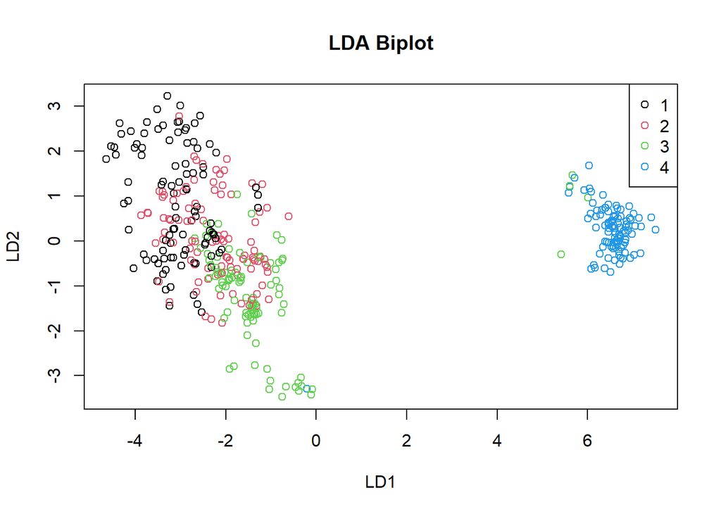

```r
# Extract the scores (LD1 and LD2)
lda_scores <- predict(lda_model)$x

# Create a biplot
plot(lda_scores[,1], lda_scores[,2], col=train_set$crime_cat,
     xlab="LD1", ylab="LD2", main="LDA Biplot")
legend("topright", legend=levels(factor(train_set$crime_cat)),
       col=1:length(levels(factor(train_set$crime_cat))), pch=1)
```

In our biplot, each point represents an observation from our training set. The color of each point corresponds to the category of crime rate. LD1 and LD2 are the first two linear discriminants.

**Next step: Save the crime categories from the test set and then remove the categorical crime variable from the test dataset. Then predict the classes with the LDA model on the test data. Cross tabulate the results with the crime categories from the test set. Comment on the results.**

```r
# Save the crime categories from the test set
actual_crime_categories <- test_set$crime_cat

# Remove the categorical crime variable from the test dataset
test_set$crime_cat <- NULL

# Predict the classes with the LDA model on the test data
predicted_crime_categories <- predict(lda_model, newdata = test_set)$class

# Cross-tabulate the results
confusion_matrix <- table(Predicted = predicted_crime_categories, Actual = actual_crime_categories)

# Print the confusion matrix
print(confusion_matrix)
```

```
##          Actual
## Predicted  1  2  3  4
##         1 15  4  1  0
##         2 11 14  6  0
##         3  2  7 19  0
##         4  0  0  2 27
```

In our cross-tabulation matrix, each row represent the predicted categories of crime rate of our LDA model, while each column represents the actual categories of crime rate from the test set. The diagonal values show the correct predictions for each category. Overall, it seems that quite a substantial number or categories was predicted correctly. Our model seems to perform best in distinguishing the category 4, while in category 1 the was quite a severe number of misclassifications. The category four represents the highest quantile of the crime rates. As there was a clear division between suburbs with low crime rates and suburbs with extremely high crime rates, this makes sense. It seems that there are several predictors that point towards the high crime rate, which makes it easy to predict.

**Next: Reload the Boston dataset and standardize the dataset. Calculate the distances between the observations. Run k-means algorithm on the dataset. Investigate what is the optimal number of clusters and run the algorithm again. Visualize the clusters (for example with the pairs() or ggpairs() functions, where the clusters are separated with colors) and interpret the results**

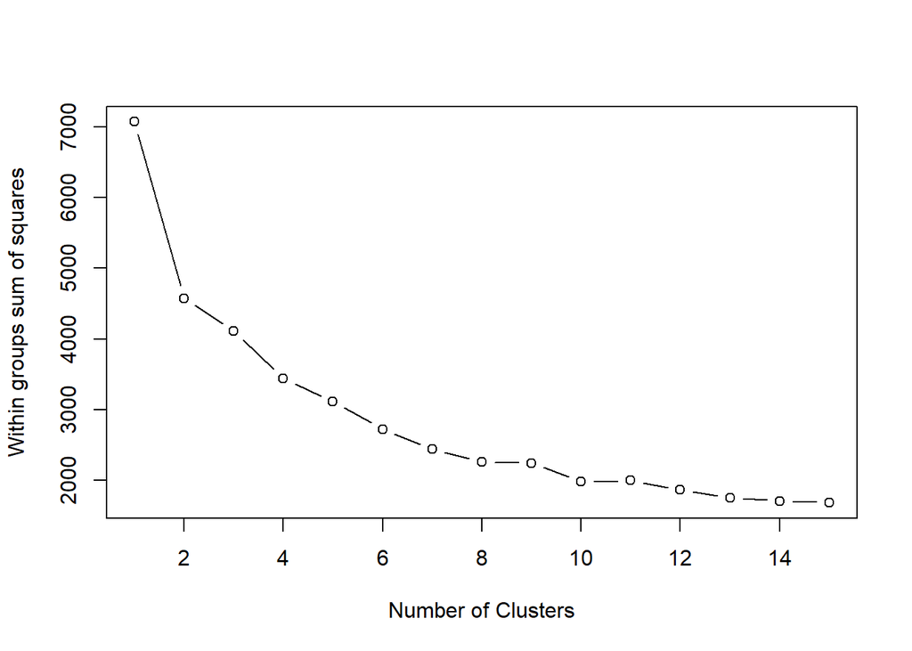

```r
library(MASS)  # Load the MASS package for the Boston dataset
data("Boston")  # Load the Boston dataset

# Standardize the dataset
Boston_scaled <- scale(Boston)
# Calculate the distances between observations
distances <- dist(Boston_scaled)
# Set a seed for reproducibility
set.seed(123)

# Run the k-means algorithm with an arbitrary number of clusters, e.g., 3
initial_kmeans <- kmeans(Boston_scaled, centers = 3, nstart = 25)

# We find the optimal number of clusters by the "elbow" method

wss <- (nrow(Boston_scaled)-1)*sum(apply(Boston_scaled,2,var))
for (i in 2:15) wss[i] <- sum(kmeans(Boston_scaled, centers=i)$withinss)

plot(1:15, wss, type="b", xlab="Number of Clusters", ylab="Within groups sum of squares")
```

In the elbow method, we want to choose the number of clusters where the rate of decrease sharply changes. Beyond this point, adding more clusters would not change the results that much. While we dont have very clear “elbow” in the picture, I will choose 8 clusters, after which the decrease is significantly lower.

Let us run the algorithm again with optimal number of clusters an visualize them:

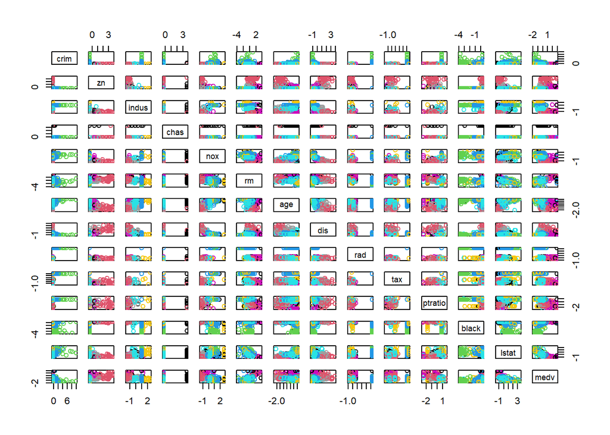

```r
optimal_kmeans <- kmeans(Boston_scaled, centers = 8, nstart = 25)

pairs(Boston_scaled, col = optimal_kmeans$cluster)
```

OKay, the pairs() function looks absolutely horrible. The colors in the graph should be pointing towards each of the category. I literally cannot see any correlations in the pairs function because the picture is so bad.